# MSBA Worskhop: Introduction to Quarto

Author

Your name here!

Published

Jul 8, 2026

## Quarto documents

Quarto documents contain both text and code cells. If you’re familiar with RMarkdown documents, Quarto documents are similar but with more functionality.

Click the **Preview** button which should render this document into a formatted HTML file. Then view this QMD document side-by-side with the HTML output.

## Header

First notice the header at the top of the document that defines the title, author, date, and other options. There are lots of other [options](https://quarto.org/docs/reference/formats/html.html) you can add.

There are multiple [output formats](https://quarto.org/docs/output-formats/all-formats.html), but we’ll just focus on HTML for now.

Look for `embed-resources: true` in the header. By default, when Quarto renders a document with plots, styling, etc., it saves those pieces (images, CSS, JavaScript) as *separate files* in a companion folder next to your `.html` file, and the HTML just points to them. `embed-resources: true` instead packs everything — every image, every bit of styling — directly *inside* the single `.html` file. That’s why every `.html` file in this workshop has it turned on: it means the rendered file is fully self-contained, so you can email it, upload it to Canvas, or send it to a classmate as one file and it’ll display correctly on their end, with nothing else needed alongside it. We’ll see exactly what goes wrong without it a bit later, once we have an actual plot to test with.

## Markdown

You can use markdown text formatting like **boldface**, *italics*, or creating lists

- Item 1
- Item 2

## Code cells

Here is a Python code cell.

```python
import pandas as pd

pd.read_csv("https://raw.githubusercontent.com/kevindavisross/msba-workshop/refs/heads/main/cereals.csv")
```

|  | name | mfr | type | calories | protein | fat | sodium | fiber | carbo | sugars | potass | vitamins | shelf | weight | cups | rating |
| --- | --- | --- | --- | --- | --- | --- | --- | --- | --- | --- | --- | --- | --- | --- | --- | --- |
| 0 | 100% Bran | N | C | 70 | 4 | 1 | 130 | 10.0 | 5.0 | 6 | 280 | 25 | 3 | 1.0 | 0.33 | 68.402973 |
| 1 | 100% Natural Bran | Q | C | 120 | 3 | 5 | 15 | 2.0 | 8.0 | 8 | 135 | 0 | 3 | 1.0 | 1.00 | 33.983679 |
| 2 | All-Bran | K | C | 70 | 4 | 1 | 260 | 9.0 | 7.0 | 5 | 320 | 25 | 3 | 1.0 | 0.33 | 59.425505 |
| 3 | All-Bran with Extra Fiber | K | C | 50 | 4 | 0 | 140 | 14.0 | 8.0 | 0 | 330 | 25 | 3 | 1.0 | 0.50 | 93.704912 |
| 4 | Almond Delight | R | C | 110 | 2 | 2 | 200 | 1.0 | 14.0 | 8 | -1 | 25 | 3 | 1.0 | 0.75 | 34.384843 |
| ... | ... | ... | ... | ... | ... | ... | ... | ... | ... | ... | ... | ... | ... | ... | ... | ... |
| 72 | Triples | G | C | 110 | 2 | 1 | 250 | 0.0 | 21.0 | 3 | 60 | 25 | 3 | 1.0 | 0.75 | 39.106174 |
| 73 | Trix | G | C | 110 | 1 | 1 | 140 | 0.0 | 13.0 | 12 | 25 | 25 | 2 | 1.0 | 1.00 | 27.753301 |
| 74 | Wheat Chex | R | C | 100 | 3 | 1 | 230 | 3.0 | 17.0 | 3 | 115 | 25 | 1 | 1.0 | 0.67 | 49.787445 |
| 75 | Wheaties | G | C | 100 | 3 | 1 | 200 | 3.0 | 17.0 | 3 | 110 | 25 | 1 | 1.0 | 1.00 | 51.592193 |
| 76 | Wheaties Honey Gold | G | C | 110 | 2 | 1 | 200 | 1.0 | 16.0 | 8 | 60 | 25 | 1 | 1.0 | 0.75 | 36.187559 |

77 rows × 16 columns

Note `python` in the start of the code cell. We’ll focus on Python, but Quarto supports other languages, including `r`. (You can use multiple languages in the same document.)

## Cell options

There are many options which control how the cell behaves. Options are specified by `#|` (hash pipe).

Use `echo` to determine whether or not the code should be shown in the formatted document.

|  | name | mfr | type | calories | protein | fat | sodium | fiber | carbo | sugars | potass | vitamins | shelf | weight | cups | rating |
| --- | --- | --- | --- | --- | --- | --- | --- | --- | --- | --- | --- | --- | --- | --- | --- | --- |
| 0 | 100% Bran | N | C | 70 | 4 | 1 | 130 | 10.0 | 5.0 | 6 | 280 | 25 | 3 | 1.0 | 0.33 | 68.402973 |
| 1 | 100% Natural Bran | Q | C | 120 | 3 | 5 | 15 | 2.0 | 8.0 | 8 | 135 | 0 | 3 | 1.0 | 1.00 | 33.983679 |
| 2 | All-Bran | K | C | 70 | 4 | 1 | 260 | 9.0 | 7.0 | 5 | 320 | 25 | 3 | 1.0 | 0.33 | 59.425505 |
| 3 | All-Bran with Extra Fiber | K | C | 50 | 4 | 0 | 140 | 14.0 | 8.0 | 0 | 330 | 25 | 3 | 1.0 | 0.50 | 93.704912 |
| 4 | Almond Delight | R | C | 110 | 2 | 2 | 200 | 1.0 | 14.0 | 8 | -1 | 25 | 3 | 1.0 | 0.75 | 34.384843 |
| ... | ... | ... | ... | ... | ... | ... | ... | ... | ... | ... | ... | ... | ... | ... | ... | ... |
| 72 | Triples | G | C | 110 | 2 | 1 | 250 | 0.0 | 21.0 | 3 | 60 | 25 | 3 | 1.0 | 0.75 | 39.106174 |
| 73 | Trix | G | C | 110 | 1 | 1 | 140 | 0.0 | 13.0 | 12 | 25 | 25 | 2 | 1.0 | 1.00 | 27.753301 |
| 74 | Wheat Chex | R | C | 100 | 3 | 1 | 230 | 3.0 | 17.0 | 3 | 115 | 25 | 1 | 1.0 | 0.67 | 49.787445 |
| 75 | Wheaties | G | C | 100 | 3 | 1 | 200 | 3.0 | 17.0 | 3 | 110 | 25 | 1 | 1.0 | 1.00 | 51.592193 |
| 76 | Wheaties Honey Gold | G | C | 110 | 2 | 1 | 200 | 1.0 | 16.0 | 8 | 60 | 25 | 1 | 1.0 | 0.75 | 36.187559 |

77 rows × 16 columns

We can use code folding to allow the code to be hidden/expanded in the formatted document.

```python
df["rating"].describe()
```

```
count    77.000000
mean     42.665705
std      14.047289
min      18.042851
25%      33.174094
50%      40.400208
75%      50.828392
max      93.704912
Name: rating, dtype: float64
```

[Cell options](https://quarto.org/docs/computations/execution-options.html) can be implemented cell by cell or globally by placing them in the header.

## Labels

It is helpful to `label` cells to help navigate the document and to allow for cross-references. Inspect the **OUTLINE** on the left in Positron to see the labeled (and unlabeled cells), as well as the section headings.

```python
df["rating"].describe()
```

```
count    77.000000
mean     42.665705
std      14.047289
min      18.042851
25%      33.174094
50%      40.400208
75%      50.828392
max      93.704912
Name: rating, dtype: float64
```

## Figures

We can produce plots as usual and use cell options to add captions.

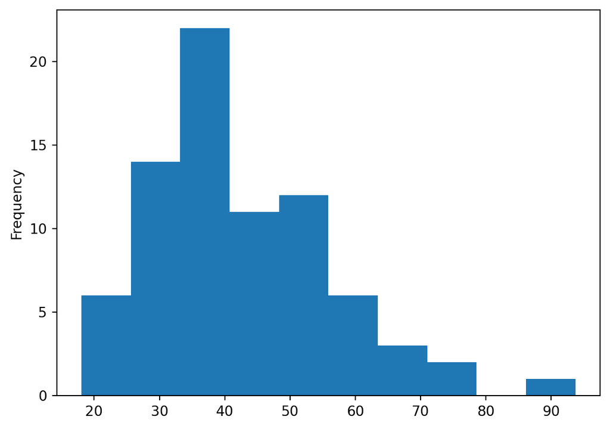

Histogram of cereal ratings

```python
df["rating"].plot.hist()
```

Adding a `label` starting with `fig-` to a cell that produces a plot will number the figure and allow us to cross-reference it.

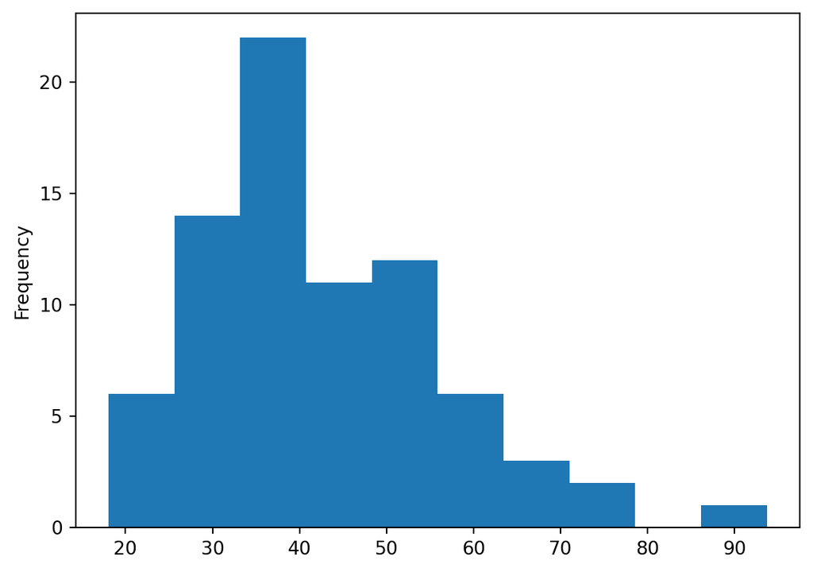

Figure 1: Histogram of cereal ratings

```python
df["rating"].plot.hist()
```

## Your turn: what does `embed-resources` actually do?

Now that we have a plot in the document, let’s see what `embed-resources` was doing for us.

1. In the header at the top of this document, change `embed-resources: true` to `embed-resources: false`.
2. Click **Preview** to re-render.
3. Look in the file browser next to your `.qmd` file — you should notice a new folder appeared (named something like `msba-workshop-quarto_files`). This is where the plot images (and the page’s styling) now live *separately* from the HTML file.
4. Copy just the `.html` file (not the new folder!) to a different location on your computer — your Desktop, for example.
5. Open that copied file directly (double-click it, or open it in a browser).
6. Look at where the plots should be. What do you see?

**TipWhat you should see (click to expand)**

Broken image icons where the plots should be, and the page may look unstyled too. The copied `.html` file still contains `<img>` tags pointing at the plot images, but it points to them using a relative path into that `_files` folder — and since you only copied the `.html` file, that folder (and the images inside it) isn’t there anymore. The file wasn’t actually self-contained; it just looked that way as long as it stayed next to its companion folder.

Now change `embed-resources` back to `true`, re-render, and repeat steps 4–6. This time the plots should show up fine, because the images are embedded directly inside the `.html` file itself — there’s nothing else it depends on.

## Cross references

Cross references follow the syntax `@label`.

Since we gave the previous figure a label we can reference it: See Figure 1 for a histogram of cereal ratings.

We can also cross reference sections; this is Section 9. (If we’re going to cross reference sections, it helps to turn on [section numbering](https://quarto.org/docs/output-formats/html-basics.html#section-numbering) in the header.)

## Equations

Use LaTeX for mathematical notation like $f(x) = e^{-x}$ or equations.

$$\Phi(z) = \int_{-\infty}^z \frac{1}{\sqrt{2\pi}} e^{-u^2/2} du
\tag{1}$$

Equations can be cross-referenced: Equation 1 defines the cdf of the standard Normal distribution.

## Inline code

Results of computations within cells can be used in the text.

There are 77 observations in the cereals data set.

We can also do computations inline: $2^{11}=$ 2048.

## Callouts

[Callouts](https://quarto.org/docs/authoring/callouts.html) are nice ways to higlight some text.

**Warning**

Each cell `label` must be unique so be careful when copying and pasting cells; duplicate labels will cause the rendering to fail.

## Tables

```python
df[["name", "calories", "rating"]].head()
```

Table 1: Just a few rows and columns of the data set

|  | name | calories | rating |
| --- | --- | --- | --- |
| 0 | 100% Bran | 70 | 68.402973 |
| 1 | 100% Natural Bran | 120 | 33.983679 |
| 2 | All-Bran | 70 | 59.425505 |
| 3 | All-Bran with Extra Fiber | 50 | 93.704912 |
| 4 | Almond Delight | 110 | 34.384843 |

Now we can reference Table 1.

## Plotnine

Note that `plotnine` is not included by default when you install Anaconda, so we first have to install it using `pip install plotnine` (`conda install plotnine` also works, if you’d rather use `conda`). Run this command in the **TERMINAL** not the console. You will only need to do this once per Python environment.

**Tip**

This installs into whichever Python environment your Terminal is currently using. If you have more than one Python installation, make sure that matches the interpreter Positron is using to run your code (the one shown in the picker, top-right) — otherwise you can “successfully install” plotnine and still get a `ModuleNotFoundError` when you try to import it. See `msba-workshop-setup.qmd` if this happens.

**Important**

Do NOT include commands like `pip install` that install packages in a Quarto document. If someone else runs your document they might end up installing packages that they don’t want or that mess up their setup.

Once `plotnine` is installed we can import it and use it as usual. If we had tried to run `from plotnine import ...` before installing the package we would have gotten an error. The reason why we didn’t get the error when we formatted our document was due to `eval: false` in the code cells below which means that the cells weren’t evaluated (run) when we rendered our Quarto document. Observe that there is no plotnine figure in the HTML output.

Now change `eval: false` to `eval: true` in the two cells below, then click the **Preview** button again, and continue comparing the Quarto and HTML documents.

```python
from plotnine import ggplot, geom_point, aes, stat_smooth, facet_wrap
```

Note that you can refer to things before they are defined: The code cell that defines Figure 2 occurs after this reference.

```python
(ggplot(df,
        aes(x = "sugars", y = "rating", color = "shelf"))
 + geom_point()
 + facet_wrap("~shelf")
 + stat_smooth(method = "lm")
 )
```

Figure 2

## Your turn!!!

Experiment with some of the many options and share with your classmates! You can look at the [Quarto Tutorial](https://quarto.org/docs/get-started/) and [Quarto Guide](https://quarto.org/docs/guide/) for some ideas.

Also get some practice exploring Positron - run some code cells in the QMD individually, type some commands in the CONSOLE, look at different panes and settings, etc.